# 🎓 Proyecto: Estadística para Data Science

#### **Resampleo mensual (`'M'`) mostrando la media de ventas**

```python
ts_mensual = ts_df.resample('ME').mean() # Me salía un warning diciendo que 'M' será deprecado y habría que utilizar 'ME'
ts_mensual
```

|  | Sales |
| --- | --- |
| 2020-01-31 | 15.570106 |
| 2020-02-29 | 22.408691 |
| 2020-03-31 | 18.882239 |
| 2020-04-30 | 11.438564 |
| 2020-05-31 | 8.519952 |
| 2020-06-30 | 13.758667 |
| 2020-07-31 | 25.805135 |
| 2020-08-31 | 32.401861 |
| 2020-09-30 | 28.602831 |
| 2020-10-31 | 20.867897 |
| 2020-11-30 | 17.752941 |
| 2020-12-31 | 24.041956 |
| 2021-01-31 | 35.874661 |
| 2021-02-28 | 42.191168 |
| 2021-03-31 | 39.643033 |
| 2021-04-30 | 30.859785 |
| 2021-05-31 | 27.876473 |
| 2021-06-30 | 34.028105 |
| 2021-07-31 | 45.228192 |
| 2021-08-31 | 52.622122 |
| 2021-09-30 | 48.801376 |
| 2021-10-31 | 41.399337 |
| 2021-11-30 | 38.098424 |
| 2021-12-31 | 45.520022 |

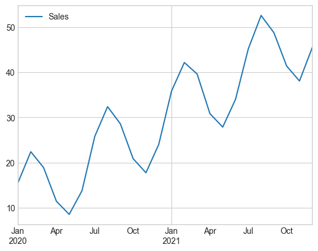

```python
ts_mensual.plot(); # Lo muestro gráficamente
```

#### **Media Móvil**

```python
# Ventana de 3 meses (la solicitada)
ts_3 = ts_mensual.rolling(window=3).mean()

# Ventana de 6 meses (para comparar)
ts_6 = ts_mensual.rolling(window=6).mean()
```

##### *Comparación de suavizados*

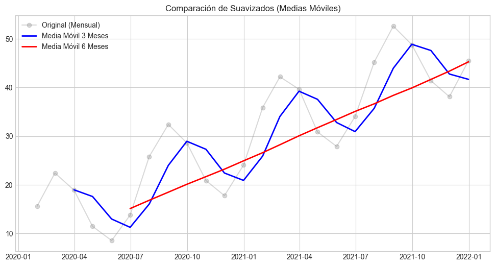

```python
plt.figure(figsize=(12, 6))
plt.plot(ts_mensual, label='Original (Mensual)', alpha=0.3, color='gray', marker='o')
plt.plot(ts_3, label='Media Móvil 3 Meses', linewidth=2, color='blue')
plt.plot(ts_6, label='Media Móvil 6 Meses', linewidth=2, color='red')
plt.title('Comparación de Suavizados (Medias Móviles)')
plt.legend()
plt.grid(True)
plt.show()
```

*Observaciones*:

- **Media Móvil 3 Meses**: Esta curva sigue de cerca los datos originales, suavizando el ruido mensual, pero capturando la oscilación estacional general.
- **Media Móvil 6 Meses**: Es más suave que la de 3 meses. Al promediar un período más largo, se reducen significativamente las variaciones estacionales esclareciendo mejor la tendencia de crecimiento a largo plazo.

Por lo que, con la ventana de 3 meses va a ser mejor para capturar patrones estacionales y ver los ciclos de ventas a corto plazo. Con la ventana de 6 meses identificaremos la tendencia a largo plazo permitiendo conocer el crecimiento o decrecimiento en general.

#### **`seasonal_decompose` para visualizar los componentes (Tendencia, Estacionalidad y ruido)**

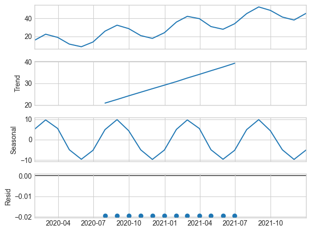

```python
result = seasonal_decompose(ts_mensual, model='additive', period=12)
result.plot()
plt.show()
```

*Observaciones*: